# Lecture #10

R - 그래픽 원그래프, 히스토그램 등

Junho Ahn

2022-09-08

## pie 함수

### pie함수의 사용법

- 범주형 자료의 각 범주별 빈도수(또는 각 범주의 비율)를 원 내부의 각도에 비례하게 그린 그림
- 범주형 변수 중 주로 명목형에 적합함

**`pie()`함수의 매개변수**  
- x: 원그래프를 그릴 값(주로 빈도) - labels: 원그래프에서 각 슬라이스에 사용할 이름, x에 이름이 없으면 인덱스를 사용함  
- radius: 원의 반지름을 설정하며 원 그래프에서 x,y축 모두 -1 ~ 1 사이의 정사각형에 그리는 것을 기본으로 하므로 적절한 반지름 설정  
- col: 원의 내부의 색깔  
- border: 선(테두리)의 색깔 - density, angle: 각 슬라이스 내부를 빗금으로 그릴 때 인치당 빗금의 갯수 및 각도 설정

**예시** (옵션에 따른 파이 그림의 형태) 빈도수 aa를 사용하여 네 개의 서로 다른 형태의 원그래프를 그린 보기이다.  
첫 번째 그림은 기본 원그래프이며, 두 번째 그림은 radius를 1로 원을 키운 것이며, 세번째는 시작하는 위치가 180인 경우이며, 마지막 그림은 원의 내부 및 테두리의 색을 다르게 설정한 것이다.

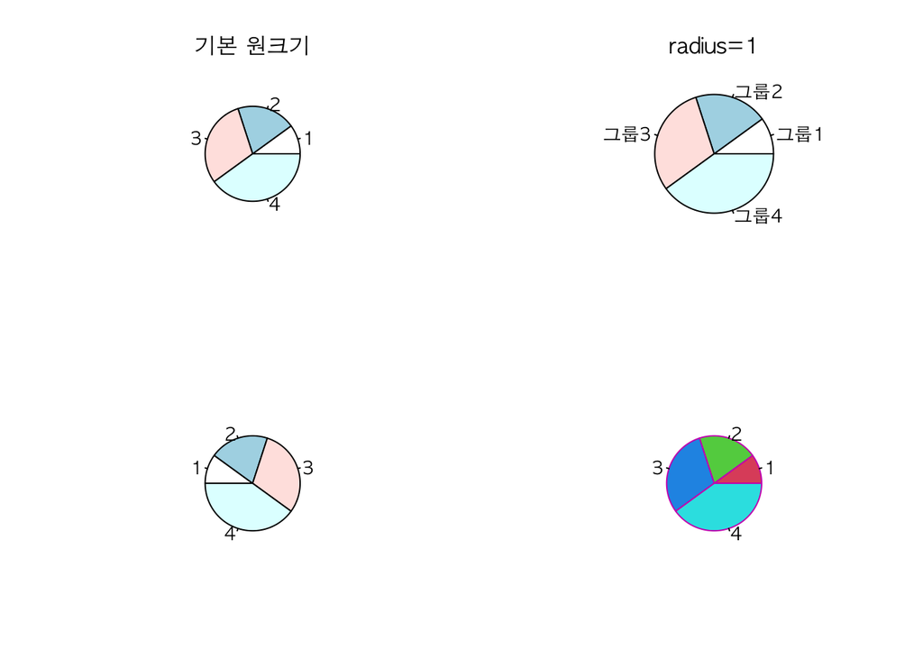

```r
aa <- c(10, 20, 30, 40)
name.aa <- c("그룹1", "그룹2", "그룹3", "그룹4")

par(mfrow=c(2,2), family = "AppleGothic")

pie(aa, main="기본 원크기")
pie(aa, labels = name.aa, radius = 1, main = "radius=1")
pie(aa, clockwise = TRUE, init.angle = 180)
pie(aa, col = 2:5, border = 6)
```

### 연속인 변수

**원그래프**  
범주형자료, 그 중에서도 명목형 자료에 적합하며 연속인 자료에는 적합하지 않으나 연속인 변수에도 함에 대한 상대적 개념을 사용할 수 있을 때 원그래프가 가능함

**예시**  
다음의 지역별 GRDP자료를 원그래프로 만들어보자.

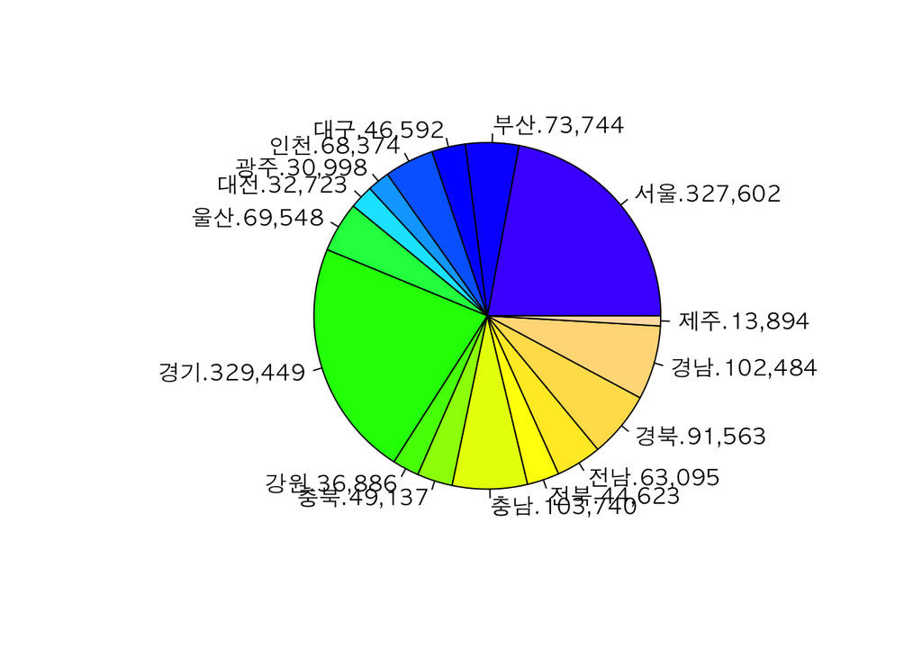

```r
area <- c("서울", "부산", "대구", "인천", "광주", "대전", "울산",
          "경기", "강원", "충북", "충남", "전북", "전남", "경북", "경남", "제주")

grdp2014 <- c(327602, 73744, 46592, 68374, 30998, 32723, 69548, 329449, 36886,
              49137, 103740, 44623, 63095, 91563, 102484, 13894)

labs <- paste(area, prettyNum(grdp2014, big.mark = ",", preserve.width = "none"), sep = ".")

par(family = "AppleGothic")
pie(grdp2014, labels = labs, radius = 0.9, col=topo.colors(length(grdp2014)))
```

- labs: 각 슬라이스에 이름을 주기 위해 만든 문자열로 지역명과 grdp의 문자열을 합한(`paste()함수`) 것
- grdp: 숫자에 콤마(,)를 넣기 위해 `prettyNum()`함수를 사용함
- `pretty()`함수의 preserve.width 옵션: 콤마(,)나 소숫점을 사용할 때 원래의 길이를 유지할 것인지 설정

### 마이크로 데이터에서 원그래프

마이크로 데이터인 경우 `table()`함수를 사용하여 원그래프를 그려야 함. barplot과 동일하게 마이크로 데이터를 직접 사용할 수 없으므로 `table()`함수를 이용하여 도수분포표를 얻은 후 그려야 함.

**예제**

BMI 자료의 종교에 대한 원그래프를 원자료 및 빈도표를 이용하여 그려보자.  
density 옵션에 따른 결과도 함께 알아본다.

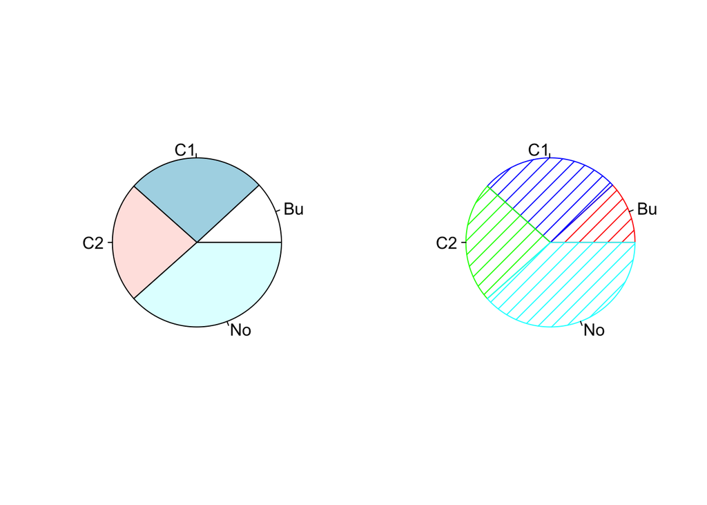

```r
par(mfrow=c(1,2))
pie(table(BMI$religion))
pie(table(BMI$religion), density = 10, col=c("red", "blue", "green", "cyan"))
```

## hist 함수

연속인 자료에 대해서 구간을 나누어 해당 구간에 포함된 자료의 빈도(또는 비율)을 기둥의 높이로 하여 막대를 연속으로 그린 그림

**막대그래프와 히스토그램의 차이**

| 막대그래프 | 히스토그램 |
| --- | --- |
| 범주형 자료에 적용되고 따라서 각 기둥이 분리되어 그려짐 | 연속인 자료에 적용되고 따라서 기둥을 분리하지 않음 |

### hist 함수의 사용법

**`hist()`함수의 매개변수**  
- x: 히스토그램을 그릴 자료를 포함한 벡터  
- freq, probability: 히스토그램에서 기둥 높이를 절대 빈도수로 할 지 상대 빈도수로 할 지 설정  
- labels: 기둥에 대한 설명을 넣을지 설정하거나 기둥의 값을 설정 (TRUE이며 해당 기둥의 빈도수가 표시됨)  
- nclass: 기둥의 개수 설정  
- breaks: 각 구간의 끝점 설정  
- col, border: 각 기둥의 내부 색깔 및 테두리 색깔 설정

**예제**

정규분포 난수를 사용하여 히스토그램을 그리되 각 기둥에 이름을 설정하는 방법을 함께 고려하여 그려보자.

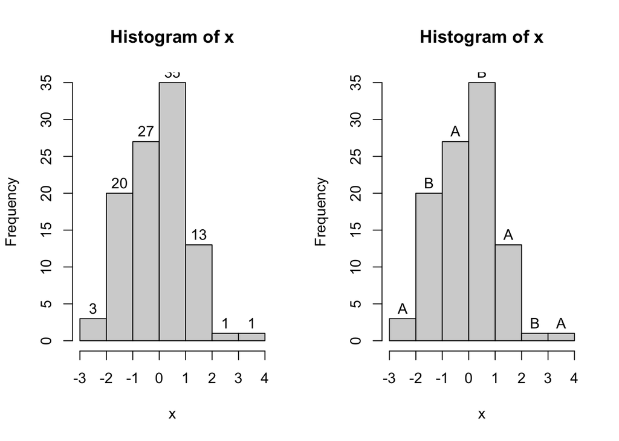

```r
x <- rnorm(100)
par(mfrow=c(1,2))
hist(x, labels = TRUE)
hist(x, labels = c("A", "B"))
```

왼쪽 히스토그램에는 각 기둥에 빈도수가 인쇄되는 반면 오른쪽에는 설정된 문자 A, B가 반복하여 출력됨.

### 두 개의 히스토그램 비교

기둥의 수 또는 기둥의 폭이 다른 히스토그램

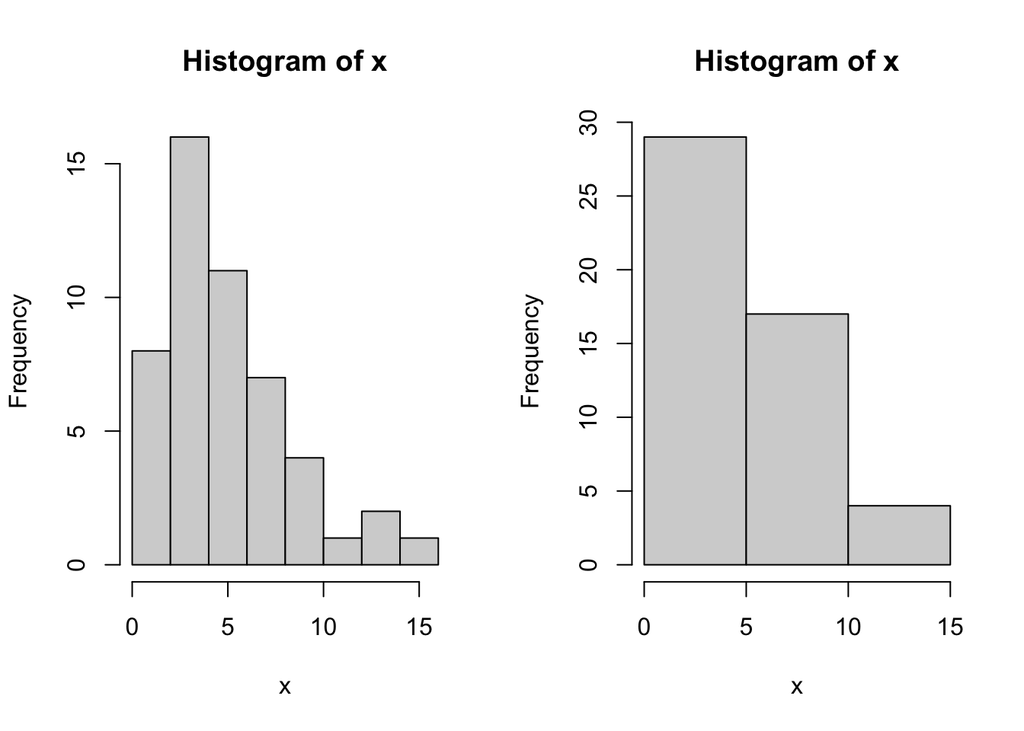

```r
x = c(8,2,10,1,1,6,6,3,4,4,3,4,5,3,14,5,3,4,7,9,5,1,10,6,2,4,6,8,3,4,13,
      3,5,7,7,6,6,7,3,8,4,4,5,1,1,12,2,9,3,15)
par(mfrow=c(1,2))
hist(x)
hist(x, nclass = 3)
```

**예시** (색깔과 구간 설정) 히스토그램을 작성할 때 기둥의 수를 설정할 수도 있지만 각 기둥이 만들어질 구간을 설정할 수도 있음 $\rightarrow$ breaks 설정

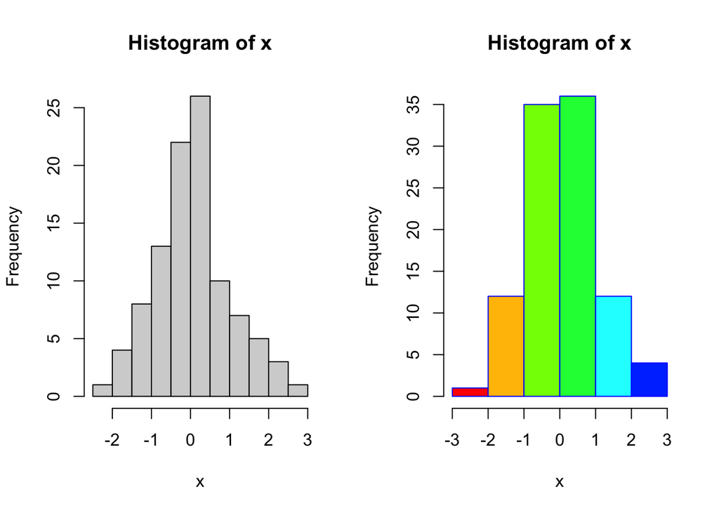

```r
par(mfrow=c(1,2))
x <- rnorm(100)
mybreaks <- seq(-3, 3, by=1)
hist(x)
hist(x, breaks = mybreaks, col=rainbow(8), border = "blue")
```

좌측은 기본값 적용, 우측은 기둥의 경계는 breaks옵션에 설정, 내부색은 `rainbow()`함수를 사용하여 무지개색, 기둥의 테두리는 blue로 설정, 양쪽 끝점이 -3, 3, breaks를 설정할 때 자료의 값 중 일부가 breaks의 범위를 벗어나 있는 경우 에러 메시지가 나올 수 있음.

### 히스토그램 함수의 출력

**`hist()`함수의 호출로 출력되는 값들**

**사용함수**

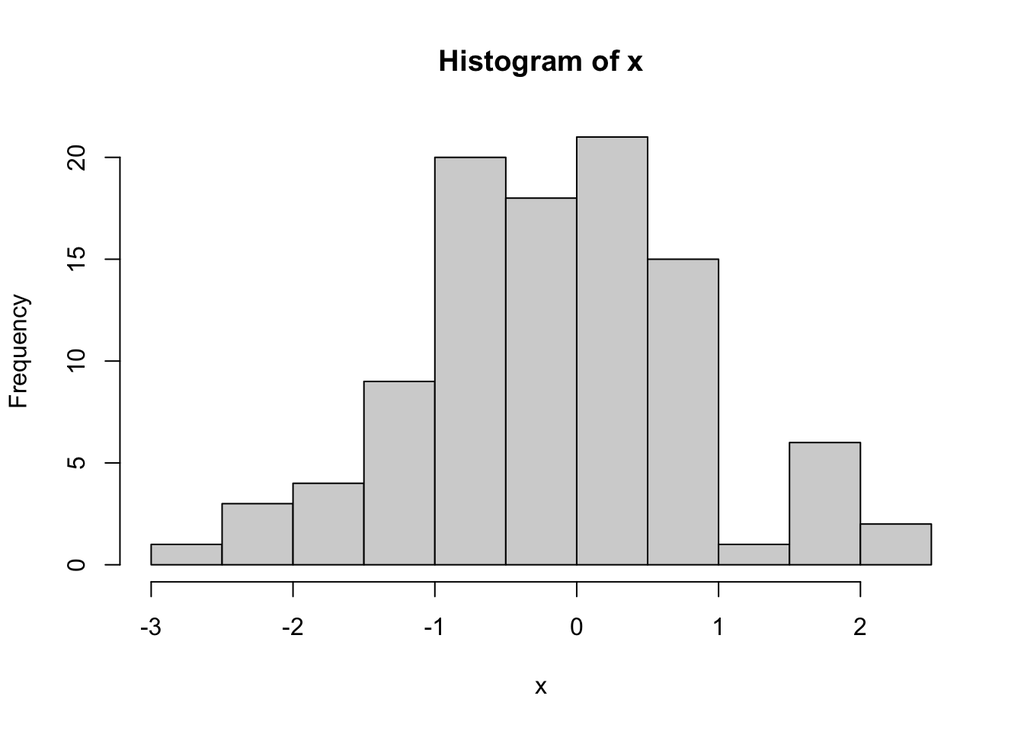

```r
x <- rnorm(100)
hist.res <- hist(x)
```

```r
hist.res
```

```
## $breaks
##  [1] -3.0 -2.5 -2.0 -1.5 -1.0 -0.5  0.0  0.5  1.0  1.5  2.0  2.5
##
## $counts
##  [1]  1  3  4  9 20 18 21 15  1  6  2
##
## $density
##  [1] 0.02 0.06 0.08 0.18 0.40 0.36 0.42 0.30 0.02 0.12 0.04
##
## $mids
##  [1] -2.75 -2.25 -1.75 -1.25 -0.75 -0.25  0.25  0.75  1.25  1.75  2.25
##
## $xname
## [1] "x"
##
## $equidist
## [1] TRUE
##
## attr(,"class")
## [1] "histogram"
```

## pyramid 함수

**연령별 인구를 인구 피라미드로 그리기**

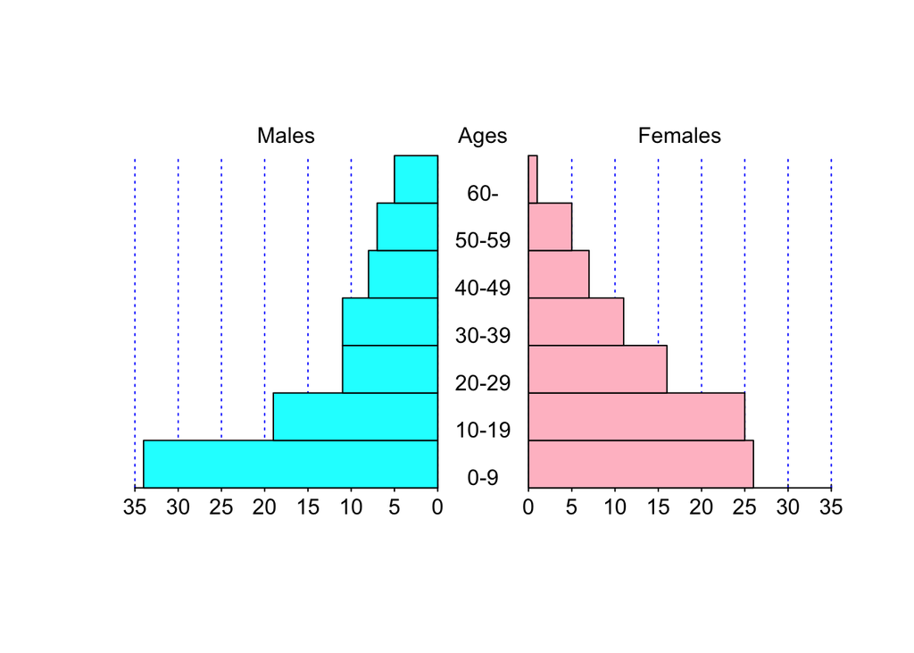

```r
library(pyramid)
ages <- c('0-9', '10-19', '20-29', '30-39', '40-49', '50-59', '60-')
males <- c(34,19,11,11,8,7,5)
females <- c(26,25,16,11,7,5,1)
data <- data.frame(males, females, ages)
pyramid(data)
```

### pyramid 패키지를 사용한 인구 피라미드

**예시**

국가통계포털 KOSIS에서 다운받은 인구주택 총조사 데이터를 이용하여 피라미드를 그려본다.  
[Download](https://kosis.kr/statHtml/statHtml.do?orgId=101&tblId=DT_1IN0001_ENG)

```r
# data preporcessing
df <- read.csv('./population2010.csv', skip = 1, encoding = "UTF-8")
df <- df[df$행정구역별 == "전국",]
colnames(df) <- c("행정구역별", "연령별", "총계","남자","여자","성비")
df <- df[-1, ]
df <- df[-c(19:24),]
```

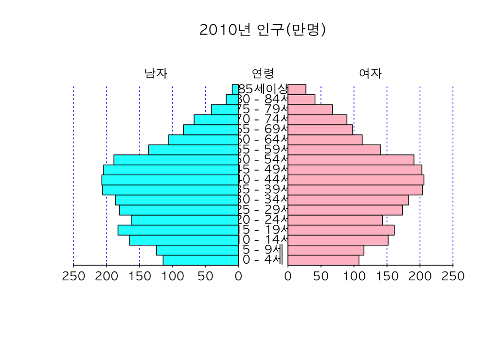

```r
par(family = "AppleGothic")
xx <- data.frame(df$남자/10000, df$여자/10000, df$연령별)
pyramid(xx, Llab = "남자", Rlab = "여자", Clab = "연령", main = "2010년 인구(만명)")
```